# Probability and Statistics

# Lab Assignment 1: Naive Bayes Classifier

### *Roman Mutel, Liubomyr Mokrytskyi, Dmytro Mykytenko*

## Introduction

During the past three weeks, you learned a couple of essential notions and theorems, and one of the most important among them is the *Bayes theorem*.

One of its applications is **Naive Bayes classifier**, which is a probabilistic classifier whose aim is to determine which class some observation probably belongs to by using the Bayes formula:
$$\mathsf{P}(\mathrm{class}\mid
\mathrm{observation})=\frac{\mathsf{P}(\mathrm{observation}\mid\mathrm{class})\mathsf{P}(\mathrm{class})}{\mathsf{P}(\mathrm{observation})}$$

Under the strong independence assumption, one can calculate $\mathsf{P}(\mathrm{observation} \mid \mathrm{class})$ as
$$\mathsf{P}(\mathrm{observation}) =
\prod_{i=1}^{n} \mathsf{P}(\mathrm{feature}_i), \qquad
\mathsf{P}(\mathrm{observation} \mid \mathrm{class}) = \prod_{i=1}^{n}
\mathsf{P}(\mathrm{feature}_i \mid \mathrm{class}),$$
where $n$ is the total number of features describing a given observation. Thus, $\mathsf{P}(\mathrm{class}|\mathrm{observation})$ now can be calculated as

$$\mathsf{P}(\mathrm{class} \mid
\mathrm{\mathrm{observation}}) = \mathsf{P}(\mathrm{class})\times
\prod_{i=1}^{n}\frac{\mathsf{P}(\mathrm{feature}_i\mid
\mathrm{class})}{\mathsf{P}(\mathrm{feature}_i)}\tag{1}$$

All the terms on the right-hand side can be estimated from the data as respective relative frequencies;  
see [this site](https://monkeylearn.com/blog/practical-explanation-naive-bayes-classifier/) for more detailed explanations.

## Data description

**Sentiment: all the text messages contained in this data set are labeled with three sentiments: positive, neutral or negative. The task is to classify some text message as the one of positive mood, negative or neutral.**

The data set consists of two files: *train.csv* and *test.csv*. The first one you will need find the probabilities distributions for each of the features, while the second one is needed for checking how well your classifier works.

```r
# here goes a list of recommended libraries,
# though you may install other ones if they are needed
library(tidytext)
library(readr)
library(dplyr)
```

```r
library(ggplot2)
```

### Data pre-processing

```r
list.files(getwd())
```

```
##  [1] "0-authors"
##  [2] "1-discrimination"
##  [3] "2-fake_news"
##  [4] "3-sentiment"
##  [5] "4-spam"
##  [6] "data.zip"
##  [7] "intro-R.Rmd"
##  [8] "Lab1_Naive_Bayes_Classifier_Templatee.Rmd"
##  [9] "Lab1_Naive_Bayes_Classifier_Templatee_files"
## [10] "Lab1_R_Team_28.html"
## [11] "NaiveBayesTeam28.html"
## [12] "NaiveBayesTeam28.R"
## [13] "stop_words.txt"
```

```r
list.files("3-sentiment")
```

```
## [1] "test.csv"  "train.csv"
```

```r
test_path <- "3-sentiment/test.csv"
train_path <- "3-sentiment/train.csv"

stop_words <- read_file("stop_words.txt")
# https://stackoverflow.com/questions/27195912/why-does-strsplit-return-a-list
splitted_stop_words <- strsplit(stop_words, split=c('\n'))
splitted_stop_words <- splitted_stop_words[[1]]
stop_words = gsub("[\r]", "", splitted_stop_words)
```

```r
train <- read.csv(file = train_path, stringsAsFactors = FALSE)
test <- read.csv(file = test_path, stringsAsFactors = FALSE)
```

```r
# note the power functional features of R bring us!
tidy_text <- unnest_tokens(train, 'splitted', 'text', token="words") %>%
             filter(!splitted %in% stop_words & nchar(splitted) > 2)
count(tidy_text, splitted,sort=TRUE)[(1:10),]
```

```
##    splitted   n
## 1      will 740
## 2   company 723
## 3       eur 701
## 4      said 436
## 5   finnish 412
## 6   million 352
## 7     sales 346
## 8       net 311
## 9   finland 303
## 10     year 297
```

### Data Visualization

Below is bar plot for words, which are longer than 3 symbols and appeared more than 10 times in **negative** sentiment statements:

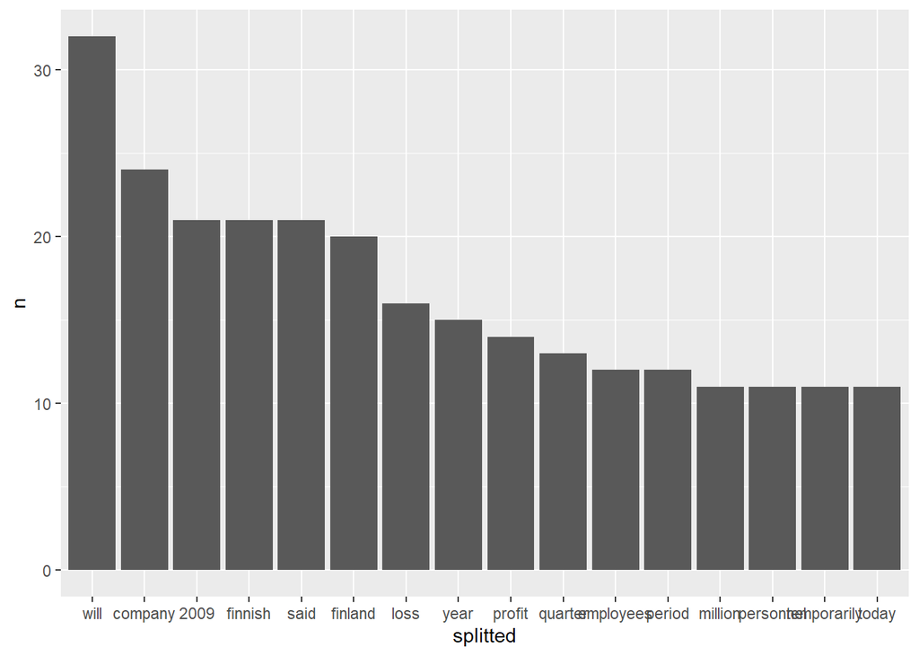

```r
negative <- tidy_text %>% filter(sentiment=="negative") %>% count(splitted,sort=TRUE) %>% filter(n > 10) %>% filter(nchar(splitted) > 3)
# sorting our dataframe
negative <- mutate(negative, splitted = reorder(splitted, 1/n))
# negative
ggplot(negative, aes(splitted, n)) + geom_col()
```

…and a similar plot for 3+ symbols long words which appeared in **positive** sentiment statements more than 100 times (there is more positive statements, than negative, so the threshold of appearances is larger than for negative words)

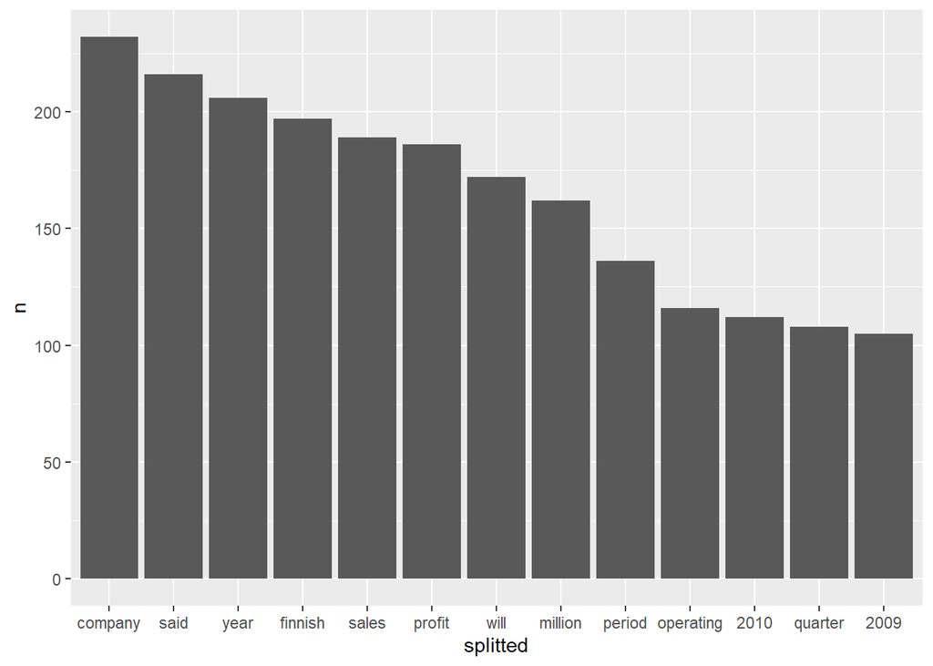

```r
positive <- tidy_text %>% filter(sentiment=="positive") %>% count(splitted,sort=TRUE) %>% filter(n > 100) %>% filter(nchar(splitted) > 3)
# sorting our dataframe
positive <- mutate(positive, splitted = reorder(splitted, 1/n))
# positive
ggplot(positive, aes(splitted, n)) +geom_col()
```

## Classifier implementation (Authors Dataset Version)

```r
naiveBayes <- setRefClass("naiveBayes",
       fields = c("fdict", "total_prob_lovecraft", "total_prob_shelley", "total_prob_poe"),
       methods = list(
                    fit = function(X, y)
                    {
                         df <- data.frame(text=X,author=y)
                         stop_words <- strsplit(read_file("stop_words.txt"), split='\n')[[1]]
                         stop_words = gsub("[\r]", "", stop_words)
                         tidy_text <- unnest_tokens(df, 'token', 'text', token="words") %>% filter(!token %in% stop_words)
                         #print(tidy_text[(1:20),])
                         prob_authors <- count(tidy_text, author)
                         total_prob_poe <<- prob_authors[1,"n"]/sum(prob_authors$n)
                         total_prob_shelley <<- prob_authors[3,"n"]/sum(prob_authors$n)
                         total_prob_lovecraft <<- prob_authors[2,"n"]/sum(prob_authors$n)

                         fdict <<- data.frame(
                           word = count(tidy_text, token, sort=TRUE)$token
                           #total = count(tidy_text, token, sort=TRUE)$n
                         )
                         lovecraft <- tidy_text %>% filter(author=="HP Lovecraft")  %>% count(token, sort=TRUE)
                         total_lovecraft = nrow(lovecraft)
                         shelley <- tidy_text %>% filter(author=="Mary Wollstonecraft Shelley ") %>% count(token, sort=TRUE)
                         total_shelley = nrow(shelley)
                         poe <- tidy_text %>% filter(author=="Edgar Alan Poe")  %>% count(token, sort=TRUE)
                         total_poe = nrow(poe)
                         total_all = n_distinct(tidy_text$token)

                         fdict$prob_lovecraft <<- seq(0,0, length=length(fdict$word))
                         fdict$prob_shelley <<- seq(0,0, length=length(fdict$word))
                         fdict$prob_poe <<- seq(0,0, length=length(fdict$word))

                         for(i in 1:nrow(fdict)){
                           i_lovecraft = lovecraft[lovecraft$token==fdict[i,"word"],]$n
                           i_shelley = shelley[shelley$token==fdict[i,"word"],]$n
                           i_poe = poe[poe$token==fdict[i,"word"],]$n

                           if (length(i_lovecraft) == 0){
                              i_lovecraft <- integer(1)
                              i_lovecraft = 0
                           }
                           if (length(i_shelley) == 0){
                              i_shelley <- integer(1)
                              i_shelley = 0
                           }
                           if (length(i_poe) == 0){
                              i_poe <- integer(1)
                              i_poe = 0
                           }

                           fdict[i,"prob_lovecraft"] <<- (i_lovecraft + 1) / (total_lovecraft + total_all)
                           fdict[i,"prob_shelley"] <<- (i_shelley + 1) / (total_shelley + total_all)
                           fdict[i,"prob_poe"] <<- (i_poe + 1) / (total_poe + total_all)
                         }
                    },
                    predict = function(message)
                    {
                         tokens = data.frame(
                           word = unlist(strsplit(message, split=" "))
                         )
                         tokens <-  filter(tokens, !word %in% stop_words & word %in% fdict$word)
                         filtered_fdict <- filter(fdict, word %in% tokens$word)
                         prob_lovecraft <- prod(filtered_fdict$prob_lovecraft) * total_prob_lovecraft
                         prob_shelley <- prod(filtered_fdict$prob_shelley) * total_prob_shelley
                         prob_poe <- prod(filtered_fdict$prob_poe) * total_prob_poe
                         # print("Probability for message:")
                         # print(message)
                         # print("P(Lovecraft|message):")
                         # print(prob_lovecraft)
                         # print("P(Shelley|message):")
                         # print(prob_shelley)
                         # print("P(Poe|message):")
                         # print(prob_poe)
                         if (prob_lovecraft > prob_shelley && prob_lovecraft > prob_poe){
                           return("HP Lovecraft")
                         }
                         else if(prob_poe > prob_shelley){
                           return("Edgar Alan Poe")
                         }
                         else{
                           return("Mary Wollstonecraft Shelley ")
                         }

                    },
                    score = function(X_test, y_test)
                    {
                         df <- data.frame(X_test,y_test)
                         df$prediction = seq(0,0,length=nrow(df))
                         counter = 0
                         for(i in (1:nrow(df))){
                           df[i,"prediction"] = .self$predict(df[i,"X_test"])
                           if(df[i,"prediction"] == df[i,"y_test"]){
                             counter = counter + 1
                           }
                         }
                         print(df[(1:20),c("X_test", "prediction", "y_test")])
                         return(counter/nrow(df))
                    }
))
test_path <- "0-authors/test.csv"
train_path <- "0-authors/train.csv"
train <- read.csv(file = train_path, stringsAsFactors = FALSE)
test <- read.csv(file = test_path, stringsAsFactors = FALSE)

model = naiveBayes()
model$fit(train$text, train$author)
model$fdict[(1:20),]
```

```
##     word prob_lovecraft prob_shelley    prob_poe
## 1    one    0.010745254  0.009419250 0.012698682
## 2   upon    0.003629764  0.004241782 0.020702528
## 3    now    0.006136030  0.008265236 0.009615929
## 4   will    0.001325152  0.009918283 0.007947282
## 5   time    0.004868493  0.004990331 0.005373607
## 6   even    0.004061879  0.005333417 0.005317043
## 7    man    0.005214185  0.004927952 0.004185757
## 8    yet    0.003428111  0.006518620 0.004383732
## 9   said    0.002880765  0.004460109 0.006759432
## 10  like    0.005934376  0.003742748 0.003591832
## 11 might    0.003543341  0.005645312 0.003818089
## 12   old    0.008354219  0.001590668 0.002630239
## 13 first    0.002995996  0.004740815 0.004836246
## 14 never    0.004148302  0.004117023 0.004157475
## 15    us    0.001930113  0.005738881 0.004581707
## 16  must    0.003773802  0.004772004 0.003620114
## 17  made    0.002995996  0.003555611 0.005458454
## 18  life    0.002880765  0.006924085 0.002064596
## 19 night    0.005271800  0.003524421 0.002743368
## 20 found    0.003831418  0.002838251 0.004694836
```

```r
model$predict("My mother's tender caresses and my father's smile of benevolent pleasure while regarding me are my first recollections.")
```

```
## [1] "Mary Wollstonecraft Shelley "
```

```r
print("Overall score:")
```

```
## [1] "Overall score:"
```

```r
model$score(test$text, test$author)
```

[output not shown]

[output cut: 27 more lines]

```
## [1] 0.7671093
```

## Summary

In this lab task, we used **Bayes’ rule** as the main mathematical model of probability search and **bag of words** technique (ignore the order of words in a sentence and count only the frequency) to improve the accuracy of the similarity search algorithm. To classify the sentences we calculated the **conditional probability** of each word given the text type, and then calculated the **product** of these probabilities for all known words in given sentence (as we assumed the words are independent, multiplying their probabilities will denote the probability of the whole sentence). Then we compared the probabilities and chose the largest one.

In the main task, we developed 3 methods of the `naiveBayes` class:

- `fit` - determines the probability of each word belonging to a specific “tag”, creates frequency dictionary
- `predict` - using the formula described above, finds the probability that the sentence is under one of the “tags”.
- `score` – tests the code and determines the accuracy of the algorithm.

Naive Bayes is a good classifying method even despite it “naive” part where we make a strong **assumption**, that word order does not matter and the probability of each word in sentence is independent, which lets us use the **bag of words** technique. Its main pros are (usually) relatively good **accuracy** and high **speed**. Its con is that in specific cases word order and word combinations may be **more useful** than single word bag of words approach. Also, no model works well if it was trained on invalid data which does not illustrate real conditions.